# Exploring the BRFSS data

## Setup

### Load packages

```r
library(ggplot2)
library(dplyr)
library(tidyr)
library(colorspace)
library(knitr)
```

### Load data

```r
load("brfss2013.RData")
```

## Part 1: Data

The Behavior Risk Factor Surveillance System (BRFSS) is the U.S health survey system to collect nationwide population-based state-level data on a multitude of health behaviors and conditions. Currently, there are 50 states as well as the District of Columbia and three U.S territories participated in this project.

The Centers of Disease Control and Prevention (CDC) conducts monthly survey via telephone with a standardized questionaire. The questionaire has three parts:

1. Core component includes fixed core questions asked each year and rotating questions (each asked in alternating years)
2. Optional modules based on specific topic such as diabetes, cancer survivorship.
3. State-added questions: CDC provides each state with the text of the core component and the optional modules. States will select optional modules and add their own quesitons in state-added questions part and then each state will send it’s finalized questionaire content to the CDC. State will conduct telephone interviews during each calendar month (7 days per week) to collect data and then submit to the CDC.

CDC limits to collect information just from the U.S residents living in a private residence or college housing who are 18 years old or older. Once these conditions are met, a random adult will be selected for the interview. Thus, the study is obsevational and only shows associational relationship.

There are some issues with this sampling method:

1. Interview format: each state will add its own questions in the state-added part and this will not standardize questionaires completedly. Because 50 states will involve in this project, we will face difficulties in attributing outcomes such as state laws and actions challenging certain health reforms. Also, states also have their own reporting requirements for diseases and conditions that must be reported to the state health department, and for reporting to disease-specific registries
2. Survey method: the BRFSS focuses on phone interview so it will have some limitations such as time and some potential interviewees might be reluctant to participate in an interview. Also, the BRFSS needs to train interviewers to ensure them to have good skill in conducting interview otherwise some drawbacks can occur such as spending too much time on unimportant questions.

This research is useful for planning, initiating, and supporting health promotion and disease prevention programs at the state and federal level, and monitoring progress toward achieving health objectives for the state and nation.

## Part 2: Research questions

**Research quesion 1:**

Are income level and having health care coverage associated with the ability to see doctor because of the cost or not?

Variables:

1. income2: Income Level
2. hlthpln1: Have Any Health Care Coverage
3. medcost: Could Not See Dr. Because Of Cost

Health care is a big concern for the U.s government. Doing analysis in this area will help the government knows whether the health care coverage will affect people’s ability to see doctor when they are sick or not. And then the government can adjust health care program to benefit its residents

**Research quesion 2:**

Age and eating habit have any association in having diabetes or not?

Variables:

1. diabete3: (Ever Told) You Have Diabetes
2. X_age_g: ages
3. X_vegesum: total number of vegetables consumed per day

The number of people having diabetes are increasing. Answering this question will help people realize the benefit of having a good eating habit for their health.

**Reasearch question 3:**

For the U.S residents who reported that they had joint pain and their limitation due to the joint pain, do physical activity levels have some association with the join pain?

Variables:

1. joinpain: Joint Pain
2. X_pacat1: Physical Activity Levels
3. lmtjoin3: limitation due to join pain

There are some people will be interested in this topic especially athletes. They may want to know if their physical activities will have any relationship with their join pain. From there, they can reschedule their activities so that they can avoid or reduce the join pain during exercises

**Research question 4:**

Are smoking habit and ages in association with the number of days they reported their health was not good?

Many people want to know whether smoking affects their health and at which age that people will have more bad bad with their health if they smoke

## Part 3: Exploratory data analysis

We will start looking the data in general

```r
dim(brfss2013)
```

```
## [1] 491775    330
```

The data has 491,775 observations and 330 variables and some variables carry NA value. To simply the EDA process, we will create a function called “complete” to just take observations that have a value for each variables

```r
complete <- function(...) {
  study <- brfss2013 %>%
    select(...)

return(study[complete.cases(study),]) #* Create new data without missing values with "complete.cases" function*
}
```

**Research quesion 1:**

Are income level and having health care coverage associated with the ability to see doctor because of the cost or not?

```r
in_med_h <- complete(income2, medcost, hlthpln1)
head(in_med_h)
```

```
##             income2 medcost hlthpln1
## 1 Less than $75,000      No      Yes
## 2   $75,000 or more      No      Yes
## 3   $75,000 or more      No      Yes
## 4 Less than $75,000      No      Yes
## 5 Less than $50,000      No      Yes
## 6   $75,000 or more      No      Yes
```

Line 2 shows “Yes” for `hlthpln1` and “No” for `medcost`. In general, when a person is covered by health insurance, they will be able to see doctor if they are sick. So, we should revalue the medcost column by using plyr function “revalue” to revalue medcost column

```r
in_med_h$medcost <- plyr::revalue(in_med_h$medcost, c("Yes" = "No", "No" = "Yes"))
head(in_med_h)
```

```
##             income2 medcost hlthpln1
## 1 Less than $75,000     Yes      Yes
## 2   $75,000 or more     Yes      Yes
## 3   $75,000 or more     Yes      Yes
## 4 Less than $75,000     Yes      Yes
## 5 Less than $50,000     Yes      Yes
## 6   $75,000 or more     Yes      Yes
```

We will look at income2 and medcost and see if income affects people’s ability to go to see doctor or not

```r
income_medcost <- in_med_h %>%
  group_by(income2, medcost) %>%
  summarize(Sum = n()) %>%
  spread(medcost, Sum) %>%
  mutate(Sum = Yes + No, `%No` = round(No/Sum*100, digit = 1))

head(income_medcost)
```

```
## # A tibble: 6 x 5
## # Groups:   income2 [8]
##   income2              No   Yes   Sum `%No`
##   <fct>             <int> <int> <int> <dbl>
## 1 Less than $10,000  7249 17916 25165  28.8
## 2 Less than $15,000  6804 19782 26586  25.6
## 3 Less than $20,000  8047 26589 34636  23.2
## 4 Less than $25,000  8262 33238 41500  19.9
## 5 Less than $35,000  7118 41542 48660  14.6
## 6 Less than $50,000  6462 54855 61317  10.5
```

According to the above table, `%No` for lower income is higher than higher income. It means that people who earn less will not afford to see doctor when they are sick. For example, for income less than $10,000; 28.8% cannot afford to see doctor. But for someone makes more than $75,000; only 3.5% cannot afford to see doctor. Thus, income does affect the ability to see doctor. We will see if these figures change when having health insurance or not

```r
income_medcost_in <- in_med_h %>%
  filter(hlthpln1 == "Yes") %>%
  group_by(income2, medcost) %>%
  summarize(Sum = n()) %>%
  spread(medcost, Sum) %>%
  mutate(Sum = Yes + No, `%No` = round(No/Sum*100, digit = 1))

head(income_medcost_in, 8)
```

```
## # A tibble: 8 x 5
## # Groups:   income2 [8]
##   income2              No    Yes    Sum `%No`
##   <fct>             <int>  <int>  <int> <dbl>
## 1 Less than $10,000  3464  15178  18642  18.6
## 2 Less than $15,000  3681  17372  21053  17.5
## 3 Less than $20,000  3858  22750  26608  14.5
## 4 Less than $25,000  4205  29029  33234  12.7
## 5 Less than $35,000  4155  37502  41657  10
## 6 Less than $50,000  4289  51221  55510   7.7
## 7 Less than $75,000  3513  58154  61667   5.7
## 8 $75,000 or more    3457 109492 112949   3.1
```

According to the new table, having health insurance will increase the ability to see doctor. We can see that all figures in the column “%No” decreases. However, we want to have a look at these figures when people dont have health insurance

```r
income_medcost_no_in <- in_med_h %>%
  filter(hlthpln1 == 'No') %>%
  group_by(income2, medcost) %>%
  summarize(Sum = n()) %>%
  spread(medcost, Sum) %>%
  mutate(Sum = Yes + No, `%No` = round(No/Sum*100, digit = 1))

head(income_medcost_no_in, 8)
```

```
## # A tibble: 8 x 5
## # Groups:   income2 [8]
##   income2              No   Yes   Sum `%No`
##   <fct>             <int> <int> <int> <dbl>
## 1 Less than $10,000  3785  2738  6523  58
## 2 Less than $15,000  3123  2410  5533  56.4
## 3 Less than $20,000  4189  3839  8028  52.2
## 4 Less than $25,000  4057  4209  8266  49.1
## 5 Less than $35,000  2963  4040  7003  42.3
## 6 Less than $50,000  2173  3634  5807  37.4
## 7 Less than $75,000  1074  2323  3397  31.6
## 8 $75,000 or more     599  2166  2765  21.7
```

we can see that income and having health care coverage are in association with the the medcost(the ability to see doctor because of medical expenses). For example, 58% of respondents are not willing to see doctor if income is less than $10,000 and having no health coverage. Yet, if covered by health policy, just 18.6% is not afford to see doctor.

TO be clearer, we will plot a bar chart to show these relationships

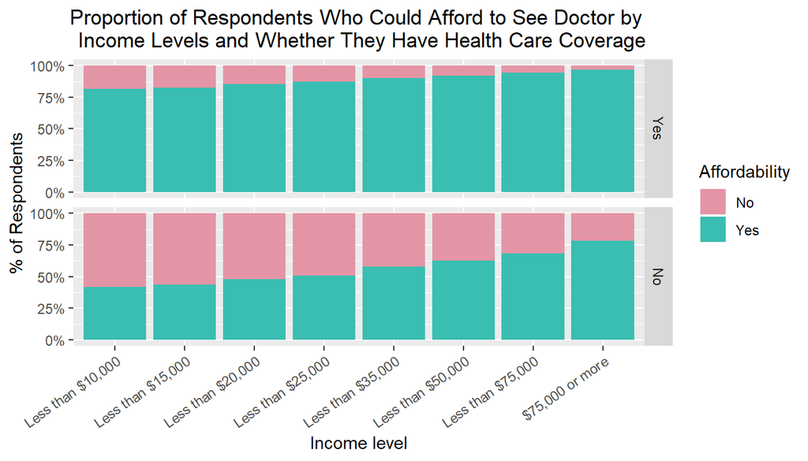

```r
ggplot(in_med_h, aes(x = income2, y = 1, fill = medcost)) +
  geom_col(position = 'fill') +
  scale_y_continuous(labels = c("0%", "25%", "50%", "75%", "100%"))  +
  scale_fill_manual(values = rainbow_hcl(2)) +
  facet_grid(hlthpln1 ~.) +
  labs(title = "Proportion of Respondents Who Could Afford to See Doctor by \n Income Levels and Whether They Have Health Care Coverage", x = "Income level", y = "% of Respondents", fill = "Affordability") +
  theme(axis.text.x = element_text(angle = 35, hjust = 1), plot.title = element_text(hjust = 0.5))
```

From the plot, we can see that income and having health care insurance will affect the ability to see doctor. Lower income people are more likely not affrod to see doctor because of the cost.

Summary:

- Question: Are income level and have health care coverage associated with the ability to see doctor because of the cost or not?
- Narrative from the Exploratory Analysis: the answer is yes. Having insurance will increase the affordability of people to go to see doctor. Also, the higher income people made, the more affordable people go to see doctor when they are sick. It looks like that lower income struggle with getting treatment when they are sick so the government should have a look at this issue to offer different type of health policy based on income so that everyone can have insurance and could afford for the medial cost.

**Research quesion 2:**

Age and eating habit have any association in having diabetes or not? We will first prepare the data for analysis

```r
diabetes <- complete(X_age_g, diabete3, X_vegesum)
```

`diabate3` has 4 observations: “Yes”, “No”, “No, pre-diabetes or borderline diabetes” and “Yes, but female told only during pregnancy”. We will just focus on Yes and No for this analysis

```r
sum <- diabetes %>%
  filter(diabete3 == c("Yes", "No")) %>%
  group_by(diabete3, X_age_g) %>%
  summarize(Sum = n()) %>%
  spread(diabete3, Sum) %>%
  mutate(Sum = Yes + No, `%Yes` = round(Yes/Sum*100, digit = 1))

head(sum)
```

```
## # A tibble: 6 x 5
##   X_age_g           Yes    No   Sum `%Yes`
##   <fct>           <int> <int> <int>  <dbl>
## 1 Age 18 to 24      129 12199 12328    1
## 2 Age 25 to 34      443 22057 22500    2
## 3 Age 35 to 44     1363 25981 27344    5
## 4 Age 45 to 54     3912 34569 38481   10.2
## 5 Age 55 to 64     8130 42052 50182   16.2
## 6 Age 65 or older 15641 57878 73519   21.3
```

We can see that percentage of people having diabetes increases by ages. Only 1% people from age 18 to 24 having diabetes while 21.3% people from the age of 65 or older said that they have been struggling with diabetes. We will visualize the relationship between diabetes and the consumption of vegetables to see if increasing more vegetables everday will help with the disease or not

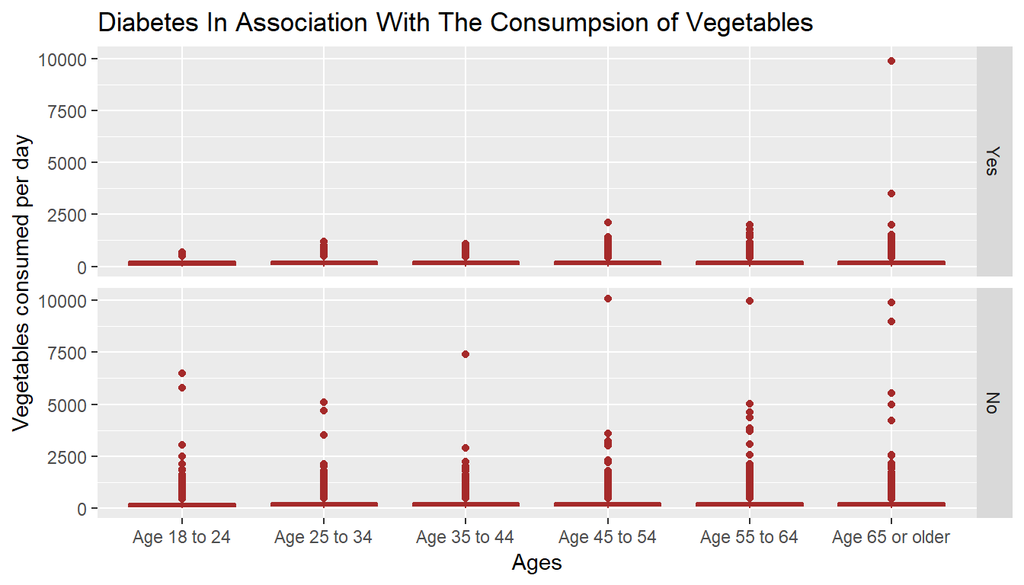

```r
aa <- diabetes %>%
  filter(diabete3 == c("Yes", "No"))

ggplot(aa, aes(x = X_age_g, y = X_vegesum)) +
  geom_boxplot(color = "brown") +
  facet_grid(diabete3 ~.) +
  labs(title = "Diabetes In Association With The Consumpsion of Vegetables", y = "Vegetables consumed per day", x = "Ages")
```

**Research question 3:**

For the U.S residents who reported that they had joint pain and their limitation due to the joint pain, do physical activity levels have some association with the pain?

We will just focus on respondents who reported that they had some limitations due to join pain and what type of activity they participated

```r
join_li_phy <- complete(X_pacat1, joinpain, lmtjoin3) %>%
  filter(joinpain != 0 & lmtjoin3 == "Yes")

head(join_li_phy)
```

```
##                X_pacat1 joinpain lmtjoin3
## 1              Inactive        7      Yes
## 2              Inactive        5      Yes
## 3 Insufficiently active        8      Yes
## 4              Inactive        8      Yes
## 5 Insufficiently active        5      Yes
## 6         Highly active        7      Yes
```

Some people may think that they will not have any join pain if they do not do any physical activies but according to the table, we can see that some respondents said that they had join pain even though they are inactive. To demtermine if there is any association between physical activity and joint pain score, we will do summary statistics

```r
sum_stat <- join_li_phy %>%
  group_by(X_pacat1) %>%
  summarize(Q1 = quantile(joinpain, .25), MEAN = mean(joinpain), MEDIAN = median(joinpain), Q3 = quantile(joinpain, .75), IQR = IQR(joinpain), SDEV = sd(joinpain)) %>%
  mutate(SKEW = ifelse(MEAN > MEDIAN, "RIGHT", "LEFT"))

sum_stat
```

```
## # A tibble: 4 x 8
##   X_pacat1                 Q1  MEAN MEDIAN    Q3   IQR  SDEV SKEW
##   <fct>                 <dbl> <dbl>  <dbl> <dbl> <dbl> <dbl> <chr>
## 1 Highly active             4  5.49      5     7     3  2.26 RIGHT
## 2 Active                    4  5.62      5     7     3  2.25 RIGHT
## 3 Insufficiently active     4  5.96      6     8     4  2.27 LEFT
## 4 Inactive                  5  6.68      7     8     3  2.22 LEFT
```

We can see that the standard deviation of four categories are pretty similar to each other. Yet, the Q1, mean, median and Q3 are difeerent for these activities. For example, Hightly active and Active are right skew so more joint pain values are less than 5.5 and 5.6, respectively. However, the insufficiently active and inactive are left skew. The insufficiently active is slightly symmetric (mean = 5.965, median = 6).

To have a better view about these relations, we will do a density plot as below:

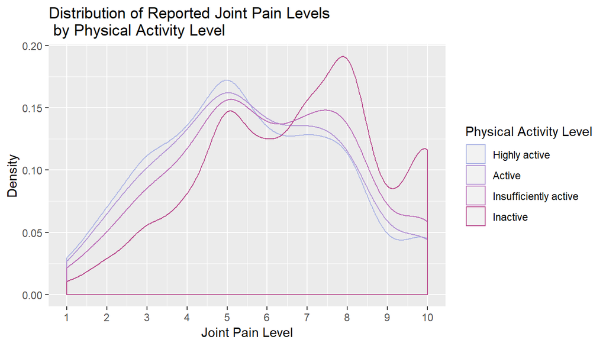

```r
ggplot(join_li_phy, aes(x = joinpain, color = X_pacat1)) +
  geom_density(adjust = 2) +
  scale_color_manual(values = rev(heat_hcl(5, h = c(0, -100), c = c(80,40), l = c(40, 75), power = 1))) +
  scale_x_continuous(breaks = c(1:10)) +
  labs(title = "Distribution of Reported Joint Pain Levels \n by Physical Activity Level", y = "Density", x = "Joint Pain Level", col = "Physical Activity Level")
```

The density plot reflects the summary statistics as Inactive distribution is denser at higher joint pain scores compared to the other categories. High active distribution is denser at the low joint pain than the other three

[figure not shown]

```r
join_li_phy_sum <- join_li_phy %>%
  group_by(X_pacat1, joinpain) %>%
  summarize(Sum = n())

cc <- scales::div_gradient_pal("brown", "purple", "pink", "Lab")(seq(0, 1, length.out = 10))

ggplot(join_li_phy_sum, aes(x = factor(X_pacat1, labels = c("Inactive", "Insufficiently active", "Active", "Highly active")), y = 1, fill = factor(joinpain, levels = c(10:1))))  +
  geom_col(position = 'fill') +
  scale_fill_manual(values = cc, labels = c('10-Worst pain', 9:2, '1-Least pain')) +
  scale_y_continuous(labels = c("0%", "25%", "50%", "75%", "100%")) +
  labs(title = "Proportion of Respondents Suffered from Joint Pain \n from Activity Levels", y = "% Respondents", x = "Physical Activity Levels", fill = "Pain Levels")
```

Summary:

- Question: For the U.S residents who reported that they had joint pain and their limitation due to the joint pain, do physical activity levels have some association with the join pain?
- Narrative from the Exploratory Analysis: The answer is yes. Increased physical activies associated with the reduction of join pain level

**Research question 4:**

Are smoking habit and ages in association with the number of days they reported their health was not good?

```r
smoke_phy <- complete(X_age_g, physhlth, X_smoker3)
head(smoke_phy)
```

```
##           X_age_g physhlth                             X_smoker3
## 1    Age 55 to 64       30                         Former smoker
## 2    Age 45 to 54        0                          Never smoked
## 3    Age 55 to 64        3 Current smoker - now smokes some days
## 4    Age 55 to 64        2                          Never smoked
## 5 Age 65 or older       10                         Former smoker
## 6    Age 45 to 54        0                          Never smoked
```

We will revalue X_smoker3

```r
smoke_phy$X_smoker3 <- plyr::revalue(smoke_phy$X_smoker3, c("Current smoker - now smokes every day" = "Smokes every day", "Current smoker - now smokes some days" = "Smokes some days"))

head(smoke_phy)
```

```
##           X_age_g physhlth        X_smoker3
## 1    Age 55 to 64       30    Former smoker
## 2    Age 45 to 54        0     Never smoked
## 3    Age 55 to 64        3 Smokes some days
## 4    Age 55 to 64        2     Never smoked
## 5 Age 65 or older       10    Former smoker
## 6    Age 45 to 54        0     Never smoked
```

we will look at these three variables but exclude respondents who reported have zero bad day with their physical health. Then, we will perform summary statistics

```r
smoke_phy_sum <- smoke_phy %>%
  filter(physhlth != 0) %>%
  group_by(X_age_g, X_smoker3) %>%
  summarize(Q1 = quantile(physhlth, .25), MEAN = mean(physhlth), MEDIAN = median(physhlth), IQR = IQR(physhlth), Q3 = quantile(physhlth, .75), SDEV = sd(physhlth))

head(smoke_phy_sum)
```

```
## # A tibble: 6 x 8
## # Groups:   X_age_g [2]
##   X_age_g      X_smoker3           Q1  MEAN MEDIAN   IQR    Q3  SDEV
##   <fct>        <fct>            <dbl> <dbl>  <dbl> <dbl> <dbl> <dbl>
## 1 Age 18 to 24 Smokes every day     2  8.52      5     8    10  8.88
## 2 Age 18 to 24 Smokes some days     2  7.24      4     6     8  8.37
## 3 Age 18 to 24 Former smoker        2  6.83      3     5     7  7.96
## 4 Age 18 to 24 Never smoked         2  5.79      3     5     7  7.15
## 5 Age 25 to 34 Smokes every day     2 10.2       5    13    15 10.1
## 6 Age 25 to 34 Smokes some days     2  9.22      5    12    14 10.0
```

We can see that for those smoke everyday, mean and median are higher than former smoker or never smoked people. Especially for old people (age 55 or more), the mean and median are higher than other age group. It means that smoking people experice more bad day with their physical health than former smoker and never smoked people. We will plot a line chart to see more about these relationships

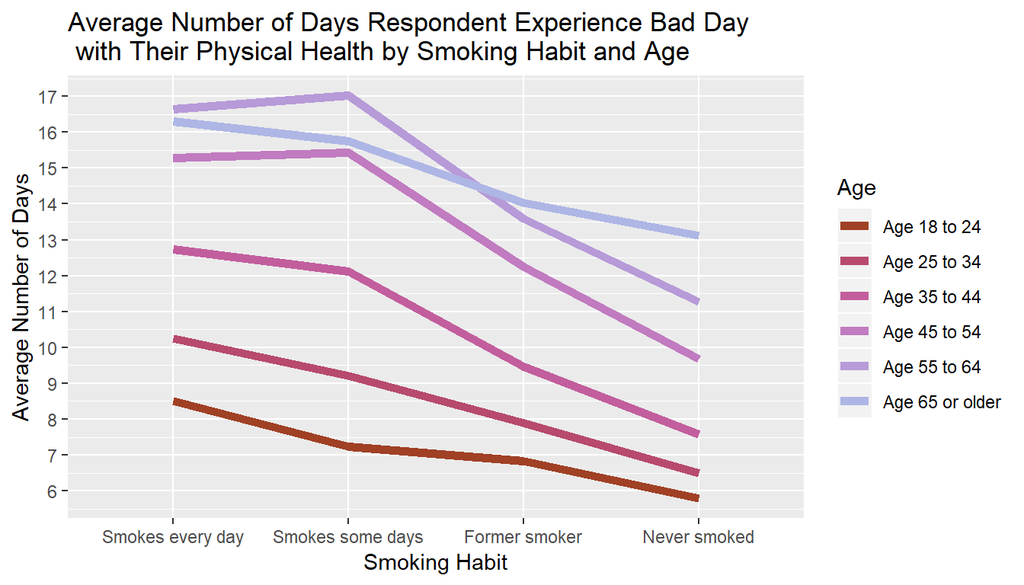

```r
ggplot(smoke_phy_sum, aes(x = X_smoker3, y = MEAN, col = X_age_g, group = X_age_g)) +
  geom_line(lwd = 2) +
  scale_y_continuous(breaks = c(0:20)) +
  scale_color_manual(values = heat_hcl(6, h = c(20, -100), c = c(80,40), l = c(40, 75), power = 1))+
  labs(title = "Average Number of Days Respondent Experience Bad Day \n with Their Physical Health by Smoking Habit and Age", x = "Smoking Habit", y = "Average Number of Days",color = "Age")
```

Summary:

- Question: Are smoking habit and ages in association with the number of days people reported to have bad day with their health?
- Narrative from the Exploratory Analysis: The answer is Yes. Smoking and older age associated with more bad days people have with their physical health